# Gene-Level Expression Comparison: Isoform-Aggregated vs Direct Quantification

# Analysis 2: Length-Corrected Gene Counts (Salmon)

Compare isoform-aggregated counts with length-corrected gene-level quantifications from Salmon. Salmon quantifications account for effective gene length, which may reduce discrepancies caused by isoform length differences.

## Load Salmon Data

```r
# Load Salmon SummarizedExperiment
se_salmon <- readRDS("../data/salmon.merged.gene_counts_scaled.rds")

cat("Loaded Salmon SummarizedExperiment:\n")
```

```
## Loaded Salmon SummarizedExperiment:
```

```r
cat("  Dimensions:", nrow(se_salmon), "genes x", ncol(se_salmon), "samples\n")
```

```
##   Dimensions: 78899 genes x 38 samples
```

```r
cat("  Assays:", paste(assayNames(se_salmon), collapse = ", "), "\n")
```

```
##   Assays: counts, abundance
```

## Run Comparison with Salmon Data

```r
results2 <- compare_gene_expression(
  dge_isoform = dge_isoform,
  gene_data = se_salmon,
  gene_id_col = gene_id_col,
  output_prefix = "comparison_nofilter_salmon"
)
```

```
## Gene-level input: SummarizedExperiment with 78899 genes
##   Parsed sample metadata from 38 samples
##
## Input dimensions:
##   Isoform-level: 1746281 transcripts x 38 samples
##   Gene-level: 78899 genes x 38 samples
##
## Filtering transcripts:
##   Total transcripts: 1746281
##   With valid gene IDs: 1746281 ( 100 %)
##   Fusion transcripts (excluded): 36188 ( 2.1 %)
##   Kept for aggregation: 1710093 ( 97.9 %)
## Aggregated to 221282 genes
##
## Matching datasets:
##   Common genes: 78899
##   Common samples (by metadata): 26
##
## TMM normalization factors:
##   Isoform range: [0.635, 1.409]
##   Gene range: [0.735, 1.254]
##
## Results saved to:
##   - results/rds/comparison_nofilter_salmon_2026.2.7.rds
##   - results/comparison_nofilter_salmon_2026.2.7.csv
```

## Salmon Results

### Overall Correlation

```r
cat("Overall correlation (Salmon length-corrected):\n")
```

```
## Overall correlation (Salmon length-corrected):
```

```r
cat("  Spearman:", round(results2$overall_correlations["spearman"], 4), "\n")
```

```
##   Spearman: 0.5764
```

```r
cat("  Pearson [log2(CPM+1)]:", round(results2$overall_correlations["pearson_log"], 4), "\n")
```

```
##   Pearson [log2(CPM+1)]: 0.5527
```

**Salmon length-corrected correlations:**

- **Spearman**: 0.576
- **Pearson on log2(CPM+1)**: 0.553

### Comparison with Analysis 1

```r
comp_table <- data.frame(
  Method = c("Standard gene counts", "Salmon length-corrected"),
  Spearman = c(results1$overall_correlations["spearman"],
               results2$overall_correlations["spearman"]),
  Pearson_log = c(results1$overall_correlations["pearson_log"],
                  results2$overall_correlations["pearson_log"])
)

kable(comp_table, digits = 4,
      caption = "Table 3: Comparison of correlation metrics between standard and length-corrected quantifications",
      col.names = c("Method", "Spearman", "Pearson [log2(CPM+1)]"))
```

Table 3: Comparison of correlation metrics between standard and length-corrected quantifications

| Method | Spearman | Pearson [log2(CPM+1)] |
| --- | --- | --- |
| Standard gene counts | 0.6212 | 0.6145 |
| Salmon length-corrected | 0.5764 | 0.5527 |

### Scatter Plot: Salmon vs Isoform-Aggregated

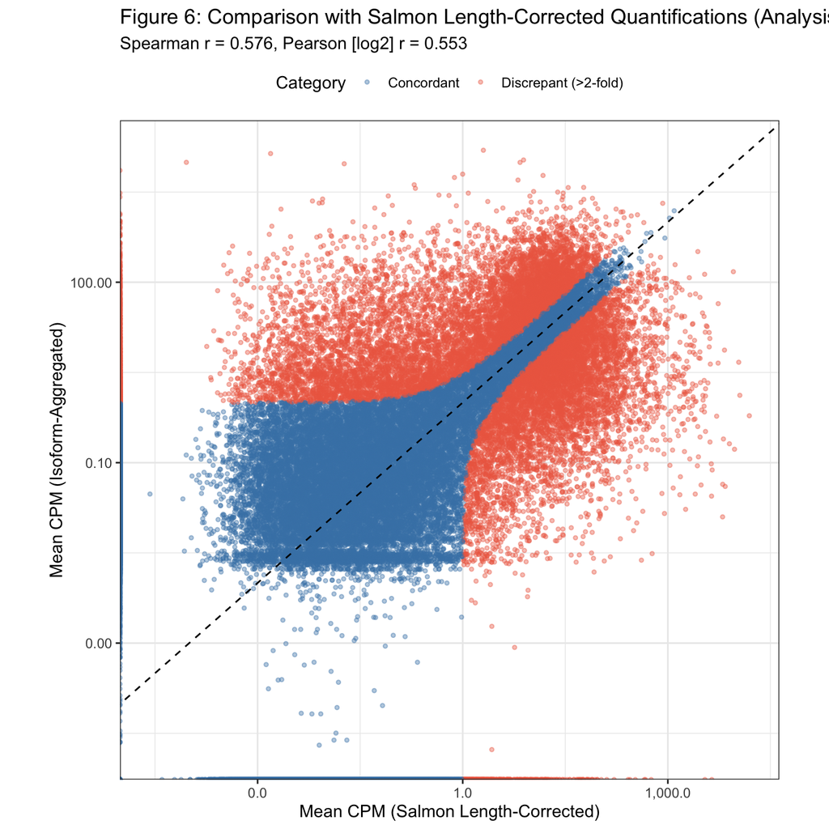

```r
# Prepare data for plotting
comp_df2 <- results2$comparison_df
plot_df2 <- comp_df2 %>%
  mutate(category = case_when(
    discrepant ~ "Discrepant (>2-fold)",
    TRUE ~ "Concordant"
  ))

# Create scatter plot
ggplot(plot_df2, aes(x = mean_cpm_gene, y = mean_cpm_isoform, color = category)) +
  geom_point(alpha = 0.4, size = 1) +
  geom_abline(slope = 1, intercept = 0, linetype = "dashed", color = "black") +
  scale_x_log10(labels = scales::comma) +
  scale_y_log10(labels = scales::comma) +
  scale_color_manual(values = c("Concordant" = "steelblue",
                                 "Discrepant (>2-fold)" = "coral2")) +
  labs(x = "Mean CPM (Salmon Length-Corrected)",
       y = "Mean CPM (Isoform-Aggregated)",
       title = "Figure 6: Comparison with Salmon Length-Corrected Quantifications (Analysis 2)",
       subtitle = paste0("Spearman r = ", round(results2$overall_correlations["spearman"], 3),
                        ", Pearson [log2] r = ", round(results2$overall_correlations["pearson_log"], 3)),
       color = "Category") +
  theme_bw(base_size = 12) +
  theme(legend.position = "top",
        aspect.ratio = 1)
```

The scatter plot shows the comparison between Salmon length-corrected quantifications and isoform-aggregated counts. Salmon quantifications account for effective gene length but show slightly lower correlation compared to standard gene counts (Analysis 1).

### Scatter Plot: Log2-Transformed Expression (Salmon)

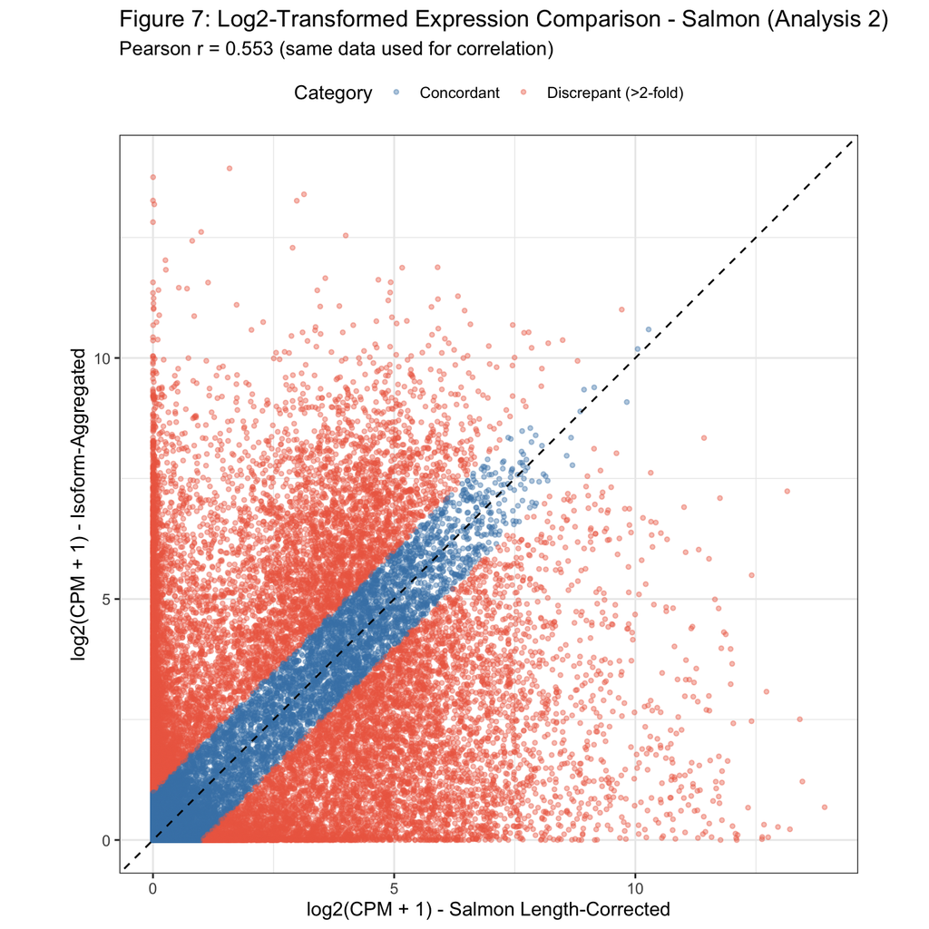

```r
# Prepare data with log2-transformed values
# These are the same values used for Pearson correlation calculation
plot_df2_log2 <- comp_df2 %>%
  mutate(
    log2_cpm_gene = log2(mean_cpm_gene + 1),
    log2_cpm_isoform = log2(mean_cpm_isoform + 1),
    category = case_when(
      discrepant ~ "Discrepant (>2-fold)",
      TRUE ~ "Concordant"
    )
  )

# Create scatter plot with log2-transformed data
ggplot(plot_df2_log2, aes(x = log2_cpm_gene, y = log2_cpm_isoform, color = category)) +
  geom_point(alpha = 0.4, size = 1) +
  geom_abline(slope = 1, intercept = 0, linetype = "dashed", color = "black") +
  scale_color_manual(values = c("Concordant" = "steelblue",
                                 "Discrepant (>2-fold)" = "coral2")) +
  labs(x = "log2(CPM + 1) - Salmon Length-Corrected",
       y = "log2(CPM + 1) - Isoform-Aggregated",
       title = "Figure 7: Log2-Transformed Expression Comparison - Salmon (Analysis 2)",
       subtitle = paste0("Pearson r = ", round(results2$overall_correlations["pearson_log"], 3),
                        " (same data used for correlation)"),
       color = "Category") +
  theme_bw(base_size = 12) +
  theme(legend.position = "top",
        aspect.ratio = 1)
```

This plot shows the Salmon comparison using log2-transformed CPM values, which is the data used for calculating the Pearson correlation (r = 0.553). The linear scale reveals the correlation structure more clearly than the log-log plot.